# Rapport Text Mining Earthworms

04/06/24

Premier bloc de code : importation des librairies.

```r
library(dplyr)
library(ggplot2)
library(tidytext)
library(tm)
library(knitr)
library(SemNetCleaner)
library(textstem)
library(SnowballC)
# WARNING : some libraries are not used but kept here at hand if the code were to be modified back (those libraries were used in previous versions of the script).
data("stop_words")
custom_stop_words <- tibble(word = c("plot","wild","slug","manipulation","apple","significant","free","led","lead","warm","fresh"),
                                      lexicon = c("custom")) # remove words that does not have the same connotation in science compared to common language.
combined_stop_words <- bind_rows(stop_words, custom_stop_words) # didn't find the way to combine tibbles earlier, wich is why some code chunks work with the two "stop words" dictionnaries separetly.
```

Deuxième bloc de code : définition des variables.

```r
#-----------------------------
earthworms <- read.csv("~/Documents/GitHub/EarthwormsMetanalysis/ExtractionBiblio/data_articles_metaanalyses.csv")
abstracts<-c()
#---------------------
names(earthworms)
```

```
## [1] "X"              "MA"             "Title"          "First.author"
## [5] "Last.author"    "Abstract"       "OnResearchgate" "DOI"
## [9] "rg_URL"
```

```r
n = nrow(earthworms)
```

Troisième bloc de code: ajout d’une colonne “aboutEarthworms”.

```r
earthworms <- earthworms %>% mutate(aboutEarthworms = rep(TRUE,n))
```

Quatrième bloc de code: Construction de la liste des abstracts.

```r
abstracts=earthworms$Abstract
```

Cinquième bloc de code : Construction d’un dataframe de tokens.

```r
 # Unnest tokens for the current abstract
unnested_tokens <- tibble(abstracts) %>%
unnest_tokens(word, abstracts)
# Append the unnested tokens to the list
unnested_tokens<-unnested_tokens%>%anti_join(stop_words)
unnested_tokens<-unnested_tokens %>% rowwise() %>% mutate(word = wordStem(word, language = "en"))
```

Analyse du dataframe: trouver les mots les plus communs dans les quatre MA confondues.

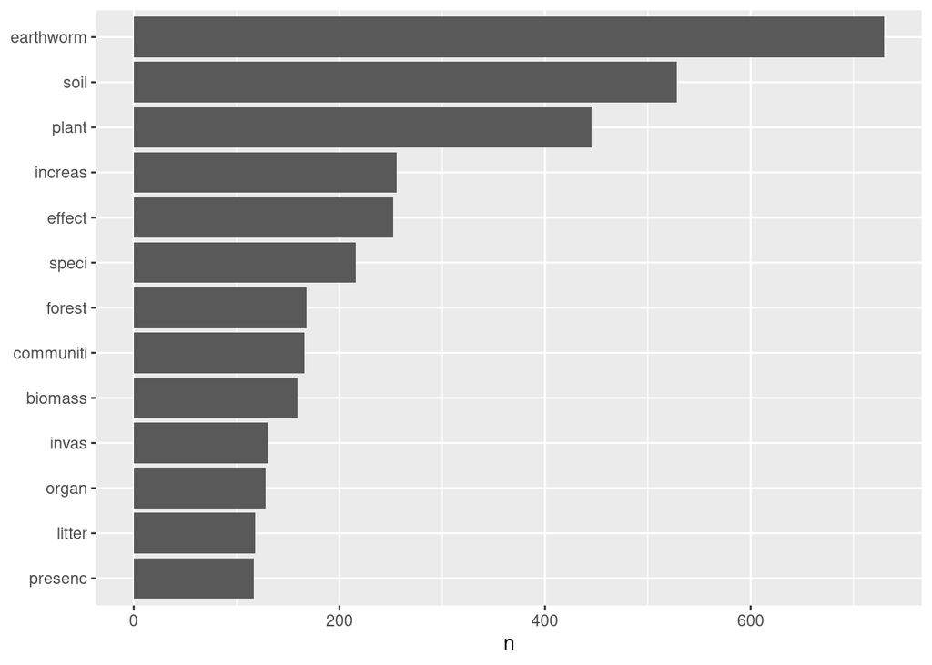

```r
ordre=unnested_tokens %>%
     count(word, sort = TRUE) %>%
     filter(n > 100) %>%
     mutate(word = reorder(word, n,decreasing=TRUE))

 ordre$word = factor(ordre$word,levels=rev(levels(ordre$word)))
 ggplot(ordre,aes(n, word)) +
     geom_col() +
     labs(y = NULL)
```

On peut voir que les trois mots les plus fréquents dans les articles des quatres métaanalyses confondues sont *earthworm*, *soil* et *plant*. On peut donc penser que les métaanalyses sont davantage portées sur le rôle écologique du ver de terre que sur l’étude des vers de terre à part entière.

MA1: “Soil chemistry turned upside down: a meta-analysis of invasive earthworm effects on soil chemical properties”  
MA2: “Earthworms affect plant growth and resistance against herbivores: A meta-analysis”  
MA3: “The unseen invaders: introduced earthworms as drivers of change in plant communities in North American forests (a meta-analysis)”  
MA4: “Earthworms increase plant production: a meta-analysis”

# Création de subsets correspondant aux 4 MA individuellement, afin de pouvoir les comparer entre elles.

## Import subset MA1:

```r
splitedData <- split(earthworms,earthworms$MA)

abstracts1<-c()
MA1 <- splitedData$MA1
nMA1 <- nrow(MA1)
abstracts1<-MA1$Abstract
unnested_tokens1 <- tibble(abstracts1) %>%
unnest_tokens(word, abstracts1)
unnested_tokens1<-unnested_tokens1 %>% anti_join(stop_words)
unnested_tokens1<-unnested_tokens1 %>% rowwise() %>% mutate(word = wordStem(word, language = "en"))
```

## Import subset MA2:

```r
abstracts2<-c()
MA2 <- splitedData$MA2
nMA2 <- nrow(MA2)
abstracts2<-MA2$Abstract
unnested_tokens2 <- tibble(abstracts2) %>%
unnest_tokens(word, abstracts2)
unnested_tokens2<-unnested_tokens2 %>% anti_join(stop_words)
unnested_tokens2<-unnested_tokens2 %>% rowwise() %>% mutate(word = wordStem(word, language = "en"))
```

## Import subset MA3:

```r
abstracts3<-c()
MA3 <- splitedData$MA3
nMA3 <- nrow(MA3)
abstracts3<-MA3$Abstract
unnested_tokens3 <- tibble(abstracts3) %>%
unnest_tokens(word, abstracts3)
unnested_tokens3<-unnested_tokens3 %>% anti_join(stop_words)
unnested_tokens3<-unnested_tokens3 %>% rowwise() %>% mutate(word = wordStem(word, language = "en"))
```

## Import subset MA4:

```r
abstracts4<-c()
MA4 <- splitedData$MA4
nMA4 <- nrow(MA4)
abstracts4<-MA4$Abstract
unnested_tokens4 <- tibble(abstracts4) %>%
unnest_tokens(word, abstracts4)
unnested_tokens4<-unnested_tokens4 %>% anti_join(stop_words)
unnested_tokens4<-unnested_tokens4 %>% rowwise() %>% mutate(word = wordStem(word, language = "en"))
```

# Création des quatre plots:

## Plot MA1 :

```r
ordre1=unnested_tokens1 %>%
     count(word, sort = TRUE) %>%
     filter(n > 25) %>%
     mutate(word = reorder(word, n,decreasing=TRUE))

 ordre1$word = factor(ordre1$word,levels=rev(levels(ordre1$word)))
 plot1<-ggplot(ordre1,aes(n, word)) +
     geom_col() +
     labs(y = NULL)
```

## Plot MA2 :

```r
ordre2=unnested_tokens2 %>%
     count(word, sort = TRUE) %>%
     filter(n > 25) %>%
     mutate(word = reorder(word, n,decreasing=TRUE))

 ordre2$word = factor(ordre2$word,levels=rev(levels(ordre2$word)))
 plot2<-ggplot(ordre2,aes(n, word)) +
     geom_col() +
     labs(y = NULL)
```

## Plot MA3 :

```r
ordre3=unnested_tokens3 %>%
     count(word, sort = TRUE) %>%
     filter(n > 25) %>%
     mutate(word = reorder(word, n,decreasing=TRUE))

 ordre3$word = factor(ordre3$word,levels=rev(levels(ordre3$word)))
 plot3<-ggplot(ordre3,aes(n, word)) +
     geom_col() +
     labs(y = NULL)
```

## Plot MA4:

```r
ordre4=unnested_tokens4 %>%
     count(word, sort = TRUE) %>%
     filter(n > 25) %>%
     mutate(word = reorder(word, n,decreasing=TRUE))

 ordre4$word = factor(ordre4$word,levels=rev(levels(ordre4$word)))
 plot4<-ggplot(ordre4,aes(n, word)) +
     geom_col() +
     labs(y = NULL)
```

# Comparaison des quatre MA:

Quels sont les mots les plus communs dans chacunes des MA?

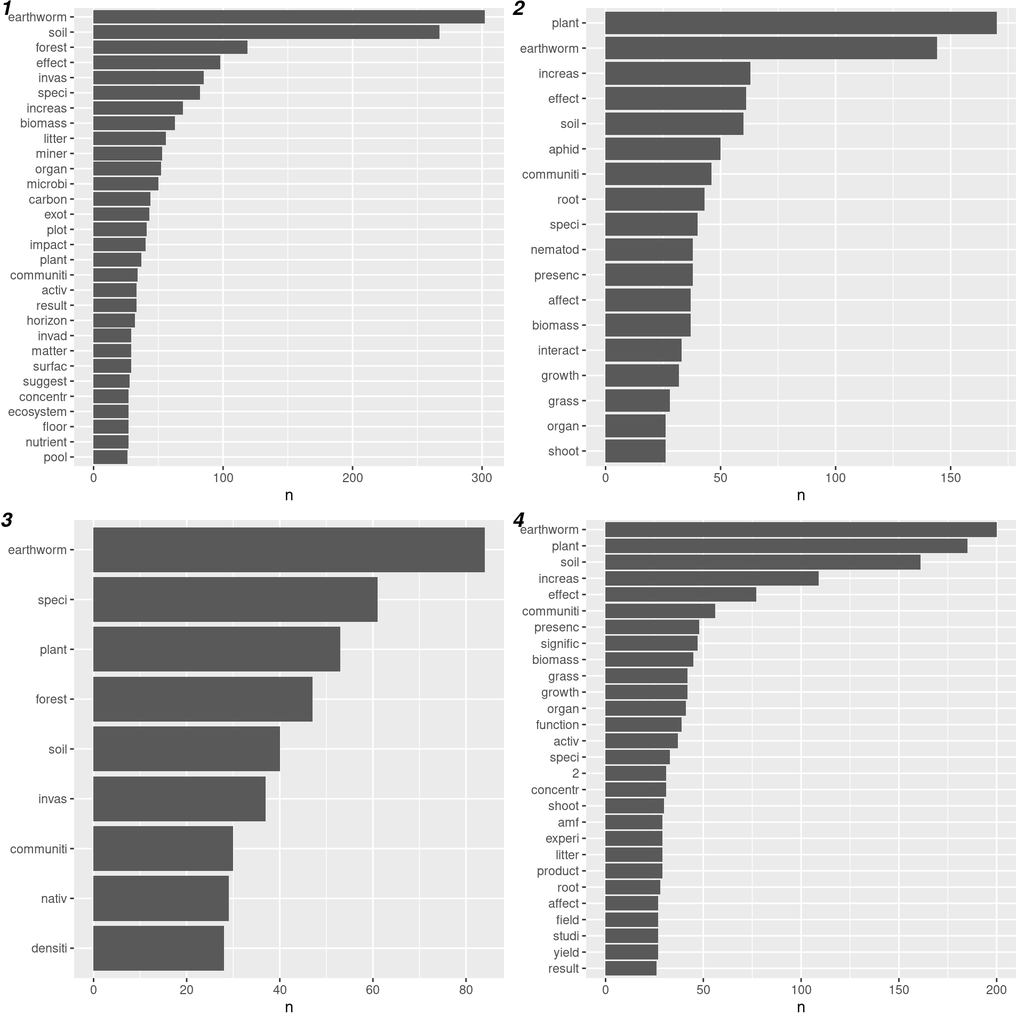

```r
library(egg)
ggarrange(plot1,plot2,plot3,plot4,widths = c(5,5),labels = c("1","2","3","4"))
```

```r
library(tidyr)

frequency1 <- bind_rows(mutate(unnested_tokens1, author = "MA1"),
                       mutate(unnested_tokens2, author = "MA2"),
                       mutate(unnested_tokens3, author = "MA3"),
                       mutate(unnested_tokens4, author = "MA4"))%>%
  mutate(word = stringr::str_extract(word, "[a-z']+")) %>%
  count(author, word) %>%
  group_by(author) %>%
  mutate(proportion = n / sum(n)) %>%
  select(-n) %>%
  pivot_wider(names_from = author, values_from = proportion) %>%
  pivot_longer(cols=c('MA2','MA3','MA4'),
               names_to = "author", values_to = "proportion")
```

```r
frequency2 <- bind_rows(mutate(unnested_tokens1, author = "MA1"),
                       mutate(unnested_tokens2, author = "MA2"),
                       mutate(unnested_tokens3, author = "MA3"),
                       mutate(unnested_tokens4, author = "MA4"))%>%
  mutate(word = stringr::str_extract(word, "[a-z']+")) %>%
  count(author, word) %>%
  group_by(author) %>%
  mutate(proportion = n / sum(n)) %>%
  select(-n) %>%
  pivot_wider(names_from = author, values_from = proportion) %>%
  pivot_longer(cols=c('MA1','MA3','MA4'),
               names_to = "author", values_to = "proportion")
```

```r
frequency3 <- bind_rows(mutate(unnested_tokens1, author = "MA1"),
                       mutate(unnested_tokens2, author = "MA2"),
                       mutate(unnested_tokens3, author = "MA3"),
                       mutate(unnested_tokens4, author = "MA4"))%>%
  mutate(word = stringr::str_extract(word, "[a-z']+")) %>%
  count(author, word) %>%
  group_by(author) %>%
  mutate(proportion = n / sum(n)) %>%
  select(-n) %>%
  pivot_wider(names_from = author, values_from = proportion) %>%
  pivot_longer(cols=c('MA1','MA2','MA4'),
               names_to = "author", values_to = "proportion")
```

# Graphe de comparaison des fréquences:

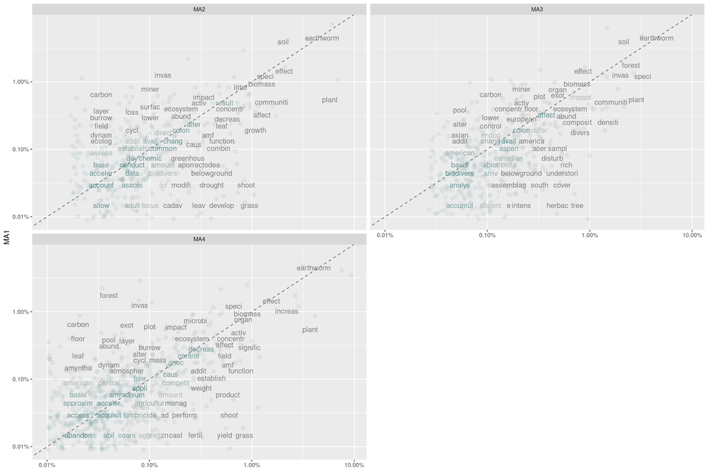

```r
library(scales)

# expect a warning about rows with missing values being removed
ggplot(frequency1, aes(x = proportion, y = `MA1`,
                      color = abs(`MA1` - proportion))) +
  geom_abline(color = "gray40", lty = 2) +
  geom_jitter(alpha = 0.1, size = 2.5, width = 0.3, height = 0.3) +
  geom_text(aes(label = word), check_overlap = TRUE, vjust = 1.5) +
  scale_x_log10(labels = percent_format()) +
  scale_y_log10(labels = percent_format()) +
  scale_color_gradient(limits = c(0, 0.001),
                       low = "darkslategray4", high = "gray75") +
  facet_wrap(~author, ncol = 2) +
  theme(legend.position="none") +
  labs(y = "MA1", x = NULL)
```

## MA1 vs MA2 :

- Les mots proches de la ligne dans ces graphiques ont des fréquences similaires dans les deux ensembles de textes, soit, dans l’ordre croissant: “accelerated”, “affecting”,“based”, “dweling”, “day”, “change”, “common”, “availability”, “negative”, “abundance”, “content”, “increase”, “activity”, “concentration”, **“litter”, “biomass”, “specie”, “soil”, “earthworm”**. On remarque que les mots les plus fréquents semblent être plus directement liés au sujet de l’article que les autres, qui paraissent plus générique au vocabulaire scientifique en écologie.
- Les mots **“invasion”, “carbon”, “layer” et “loss”** sont plus fréquents dans la MA1 que dans la MA2, tandis que les mots **“plant”, “root”, “shoot” et “grass”** sont plus fréquents dans la MA2 que de la MA1.
- Les mots **“specie”, “effect”, “soil” et “earthworm”** représentent entre 1 et 10% des mots totaux de chaque métaanalyse pour les métaanalyses 1 et 2 (échelle logarithmique).

## MA1 vs MA3 :

- Les mots proches de la ligne dans ces graphiques ont des fréquences similaires dans les deux ensembles de textes, soit, dans l’ordre croissant: “assessed”, “basal”, “abundant”, “abiotic”, “day”, “biotic”, “avalability”, “compared”, “america”, “invasive”, “european”, “abundance”, “study”, “nutrient”, “increased”, “exotic”, “ecosystem”, “impact”, “litter”, “biomass”, “effect”, **“invasion”, “forest”, “specie”, “soil”, “earthworm”**. On remarque que certains mots dont la fréquence est proches pourraient peut-être faire partie du même groupe de mots (comme **“invasive european”**,**“nutrient increased”**, **“ecosystem impact”** ou encore **“litter biomass”**.)
- Les mots **“pool”, “carbon”, et “microbial** sont plus fréquents dans la MA1 que dans la MA3, tandis que les mots **“cover”, “tree”, “density” et “plant”** sont plus fréquents dans la MA3 que de la MA1.
- Les mots **“specie”, “forest,”soil” et “earthworm”** représentent entre 1 et 10% des mots totaux de chaque métaanalyse pour les métaanalyses 1 et 3 (échelle logarithmique). On peut remarquer une forte ressemblance avec les résultats obtenus entre les MA 1 et 2.

## MA1 vs MA4 :

- Les mots proches de la ligne dans ces graphiques ont des fréquences similaires dans les deux ensembles de textes, soit, dans l’ordre croissant: “access”,“acquisition”,“data”,“australia”, “amonium”, “applied”, “analysis”, “due”, “mass”, “direct”, “affect”, “system”, “native”, “ecosystem”, “density”, “experiment”, “organic”, “activity”, “litter”, “community”, “biomass”, “specie”, **effect, earthworm**. On remarque que certains mots dont la fréquence est proches pourraient peut-être faire partie du même groupe de mots (comme **acquisition data**, **direct effect**, **native ecosystem**, ou encore **litter community**).
- Les mots **“forest”,“invasion”, “carbon” et “floor”** sont plus fréquents dans la MA1 que dans la MA4, tandis que les mots **“invader”, “functional”, “grassland”, “grass” et “plant”** sont plus fréquents dans la MA4 que de la MA1.
- Les mots **“effect” et “earthworm”** représentent entre 1 et 10% des mots totaux de chaque métaanalyse pour les métaanalyses 1 et 4 (échelle logarithmique).

## Analyse globale:

# Tests de corrélation:

Quel est le degré de corrélation entre les fréquences de mots de chaque métaanalyse ?

## MA2 VS MA1

```r
cor.test(data = frequency1[frequency1$author == "MA2",],
         ~ proportion + `MA1`)
```

```
##
##  Pearson's product-moment correlation
##
## data:  proportion and MA1
## t = 16.521, df = 337, p-value < 2.2e-16
## alternative hypothesis: true correlation is not equal to 0
## 95 percent confidence interval:
##  0.6055880 0.7238922
## sample estimates:
##       cor
## 0.6689551
```

## MA3 VS MA1

```r
cor.test(data = frequency1[frequency1$author == "MA3",],
         ~ proportion + `MA1`)
```

```
##
##  Pearson's product-moment correlation
##
## data:  proportion and MA1
## t = 25.413, df = 369, p-value < 2.2e-16
## alternative hypothesis: true correlation is not equal to 0
## 95 percent confidence interval:
##  0.7574403 0.8319765
## sample estimates:
##       cor
## 0.7977354
```

## MA4 VS MA1

```r
cor.test(data = frequency1[frequency1$author == "MA4",],
         ~ proportion + `MA1`)
```

```
##
##  Pearson's product-moment correlation
##
## data:  proportion and MA1
## t = 28.579, df = 562, p-value < 2.2e-16
## alternative hypothesis: true correlation is not equal to 0
## 95 percent confidence interval:
##  0.7337336 0.8013119
## sample estimates:
##       cor
## 0.7696699
```

## MA3 VS MA2

```r
cor.test(data = frequency2[frequency2$author == "MA3",],
         ~ proportion + `MA2`)
```

```
##
##  Pearson's product-moment correlation
##
## data:  proportion and MA2
## t = 18.2, df = 224, p-value < 2.2e-16
## alternative hypothesis: true correlation is not equal to 0
## 95 percent confidence interval:
##  0.7138335 0.8202087
## sample estimates:
##       cor
## 0.7723822
```

## MA4 VS MA2

```r
cor.test(data = frequency2[frequency2$author == "MA4",],
         ~ proportion + `MA2`)
```

```
##
##  Pearson's product-moment correlation
##
## data:  proportion and MA2
## t = 31.618, df = 467, p-value < 2.2e-16
## alternative hypothesis: true correlation is not equal to 0
## 95 percent confidence interval:
##  0.7944275 0.8524116
## sample estimates:
##       cor
## 0.8255868
```

## MA4 VS MA3

```r
cor.test(data = frequency3[frequency3$author == "MA4",],
         ~ proportion + `MA3`)
```

```
##
##  Pearson's product-moment correlation
##
## data:  proportion and MA3
## t = 18.105, df = 306, p-value < 2.2e-16
## alternative hypothesis: true correlation is not equal to 0
## 95 percent confidence interval:
##  0.6604871 0.7691044
## sample estimates:
##       cor
## 0.7191607
```

## Tableau récapitulatif :

[output not shown]

MA1: “Soil chemistry turned upside down: a meta-analysis of invasive earthworm effects on soil chemical properties”  
MA2: “Earthworms affect plant growth and resistance against herbivores: A meta-analysis”  
MA3: “The unseen invaders: introduced earthworms as drivers of change in plant communities in North American forests (a meta-analysis)”  
MA4: “Earthworms increase plant production: a meta-analysis”

# Analyse de sentiment:

## Premiers graphiques.

On commence par construire des Tibbles contenant chaque mot exprimant un sentiment positif ou négatif (colonne *word*), puis on compte le nombre d’occurence de chaque mot (colonne *n*).

```r
library(tidytext)
bing<-get_sentiments("bing")
bingStem <- bing %>% mutate(word = wordStem(word)) %>% unique()

senti1<-unnested_tokens1 %>%
  inner_join(bing) %>%
  count(word, sort = TRUE)

senti2<-unnested_tokens2 %>%
  inner_join(bing) %>%
  count(word, sort = TRUE)

senti3<-unnested_tokens3 %>%
  inner_join(bing) %>%
  count(word, sort = TRUE)

senti4<-unnested_tokens4 %>%
  inner_join(bing) %>%
  count(word, sort = TRUE)
```

On ne conserve que les dix premières valeurs et les dix dernières valeurs, afin de pouvoir produire des graphiques plus lisibles ne conservant que les valeurs extrêmes.

```r
library(tidyr)
MA1_senti <- senti1 %>%
  inner_join(get_sentiments("bing")) %>%
  anti_join(custom_stop_words, by = c("word")) %>%
  pivot_wider(names_from = sentiment, values_from = n, values_fill = 0) %>%
  mutate(sentiment = positive - negative)
sub1_MA1_senti<-MA1_senti %>%
    arrange(sentiment) %>%
    slice(1:10)
sub2_MA1_senti<-MA1_senti %>%
    arrange(desc(sentiment)) %>%
    slice(1:10)
sub_MA1_senti<-bind_rows(sub1_MA1_senti, sub2_MA1_senti)
```

On réalise un premier barplot de sentiment à titre d’exemple, en associant à chaque mot positif l’indice +1, et à chaque mot négatif l’indice -1. On représente ensuite cela graphiquement chaque mot en abscisse et la somme de ses indices (dont la valeur dépend de sa connotation et du nombre d’occurences) en ordonnées. On peut noter que certains mots neutres dans un contexte scientifique (comme “plot” ou “manipulation”) ont été rajoutés au dictionaire de “stop words”, pour éviter qu’ils soient considérés à tort comme des mots à valence négative.

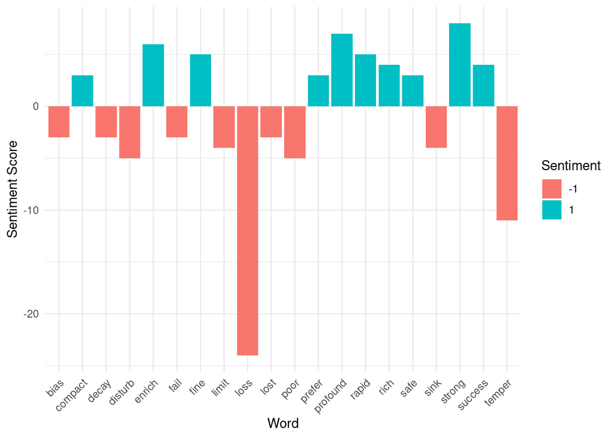

```r
ggplot(sub_MA1_senti, aes(x = word, y = sentiment, fill = factor(sign(sentiment)))) +
  geom_bar(stat = "identity") +
  labs(x = "Word", y = "Sentiment Score", fill = "Sentiment") +
  theme_minimal() +
  theme(axis.text.x = element_text(angle = 45, hjust = 1))
```

On répète le processus pour comparer les métaanalyses 1,2,3 et 4.

```r
library(tidyr)
library(ggplot2)

plot_sentiment_subset <- function(senti) {
  MA_senti <- senti %>%
    inner_join(bingStem) %>%
    pivot_wider(names_from = sentiment, values_from = n, values_fill = 0) %>%
    mutate(sentiment = positive - negative)

  sub1_MA_senti <- MA_senti %>%
    anti_join(custom_stop_words, by = c("word")) %>%
    arrange(sentiment) %>%
    slice(1:5)

  sub2_MA_senti <- MA_senti %>%
    anti_join(custom_stop_words, by = c("word")) %>%
    arrange(desc(sentiment)) %>%
    slice(1:5)

  sub_MA_senti <- bind_rows(sub1_MA_senti, sub2_MA_senti)

  ggplot(sub_MA_senti, aes(x = word, y = sentiment, fill = factor(sign(sentiment)))) +
    geom_bar(stat = "identity") +
    labs(x = "Word", y = "Sentiment Score", fill = "Sentiment") +
    theme_minimal() +
    theme(axis.text.x = element_text(angle = 45, hjust = 1))
}

plot_senti1<-plot_sentiment_subset(senti1)
plot_senti2<-plot_sentiment_subset(senti2)
plot_senti3<-plot_sentiment_subset(senti3)
plot_senti4<-plot_sentiment_subset(senti4)
```

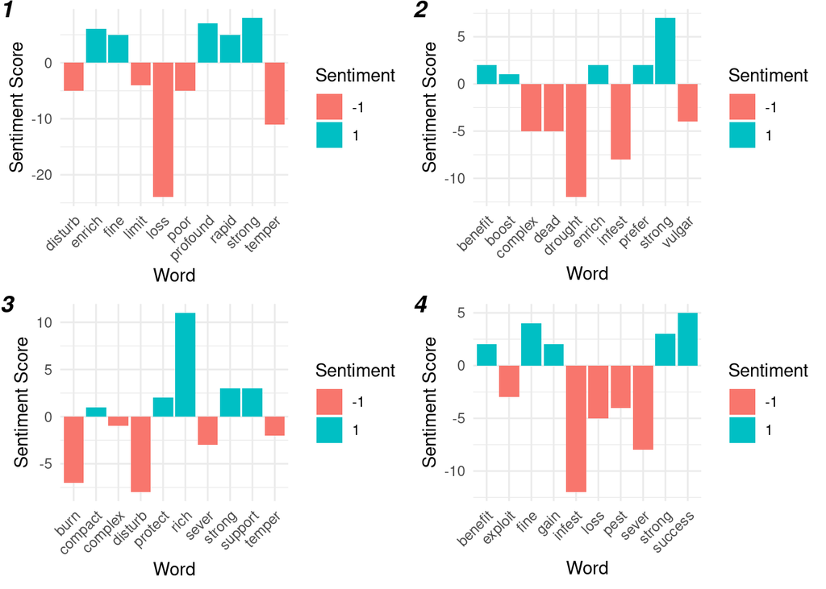

```r
library(egg)
ggarrange(plot_senti1,plot_senti2,plot_senti3,plot_senti4,widths = c(2,2),labels = c("1","2","3","4"))
```

On peut constater qu’il n’y a aucun mot négatif commun à tous les corpus. Le mot *“disturb”* n’est retrouvé que dans les MA 1 et 3, et le mot *“infest”* seulement dans les MA 2 et 4. On peut aussi remarquer que le mot *“loss”* n’est retrouvé que dans les MA1 et 4, ce qui semble indiquer que les effets négatifs relevés ne sont pas forcément liés à des pertes de caractéristiques. Le mot *“sever”*, à l’inverse, n’est retrouvé que dans les MA3 et 4, ce qui signifie peut-être qu’elles sont plus “quantitatives” que les deux autres. On peut enfin constater que le mot *“loss”* est le mot avec le score négatif le plus important des quatre graphiques, représenté dans la MA1.

MA1: “Soil chemistry turned upside down: a meta-analysis of invasive earthworm effects on soil chemical properties”  
MA2: “Earthworms affect plant growth and resistance against herbivores: A meta-analysis”  
MA3: “The unseen invaders: introduced earthworms as drivers of change in plant communities in North American forests (a meta-analysis)”  
MA4: “Earthworms increase plant production: a meta-analysis”

## Contribution de chaque terme au score final de sentiment.

```r
bing_word_counts1 <- unnested_tokens1 %>%
  inner_join(bingStem) %>%
  count(word, sentiment, sort = TRUE) %>%
  mutate(MA="MA1") %>%
  ungroup()
bing_word_counts2 <- unnested_tokens2 %>%
  inner_join(bingStem) %>%
  count(word, sentiment, sort = TRUE) %>%
  mutate(MA="MA2") %>%
  ungroup()
bing_word_counts3 <- unnested_tokens3 %>%
  inner_join(bingStem) %>%
  count(word, sentiment, sort = TRUE) %>%
  mutate(MA="MA3") %>%
  ungroup()
bing_word_counts4 <- unnested_tokens4 %>%
  inner_join(bingStem) %>%
  count(word, sentiment, sort = TRUE) %>%
  mutate(MA="MA4") %>%
  ungroup()
```

```r
contrib1<-bing_word_counts1 %>%
  anti_join(custom_stop_words, by = c("word")) %>%
  group_by(sentiment) %>%
  slice_max(n, n = 10) %>%
  ungroup() %>%
  mutate(word = reorder(word, n)) %>%
  ggplot(aes(n, word, fill = sentiment)) +
  geom_col(show.legend = FALSE) +
  facet_wrap(~sentiment, scales = "free_y") +
  labs(x = "Contribution to sentiment",
       y = NULL)

contrib2<-bing_word_counts2 %>%
  anti_join(custom_stop_words, by = c("word")) %>%
  group_by(sentiment) %>%
  slice_max(n, n = 10) %>%
  ungroup() %>%
  mutate(word = reorder(word, n)) %>%
  ggplot(aes(n, word, fill = sentiment)) +
  geom_col(show.legend = FALSE) +
  facet_wrap(~sentiment, scales = "free_y") +
  labs(x = "Contribution to sentiment",
       y = NULL)

contrib3<-bing_word_counts3 %>%
  anti_join(custom_stop_words, by = c("word")) %>%
  group_by(sentiment) %>%
  slice_max(n, n = 10) %>%
  ungroup() %>%
  mutate(word = reorder(word, n)) %>%
  ggplot(aes(n, word, fill = sentiment)) +
  geom_col(show.legend = FALSE) +
  facet_wrap(~sentiment, scales = "free_y") +
  labs(x = "Contribution to sentiment",
       y = NULL)

contrib4<-bing_word_counts4 %>%
  anti_join(custom_stop_words, by = c("word")) %>%
  group_by(sentiment) %>%
  slice_max(n, n = 10) %>%
  ungroup() %>%
  mutate(word = reorder(word, n)) %>%
  ggplot(aes(n, word, fill = sentiment)) +
  geom_col(show.legend = FALSE) +
  facet_wrap(~sentiment, scales = "free_y") +
  labs(x = "Contribution to sentiment",
       y = NULL)
```

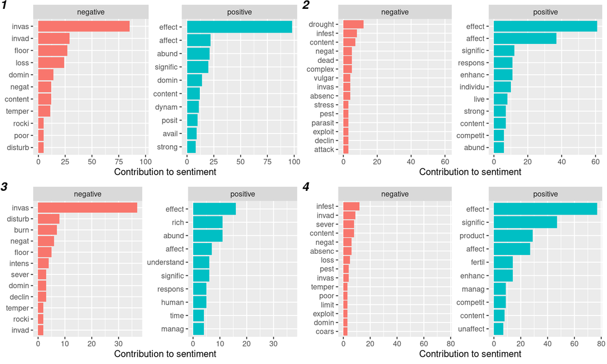

```r
library(egg)
ggarrange(contrib1,contrib2,contrib3,contrib4,widths = c(2,2),labels = c("1","2","3","4"))
```

Tout d’abord, il faut noter que les graphiques ne sont pas à la même échelle en abscisse. Cela ne pose en théorie pas de problème pour interpréter les résultats au cas par cas, mais cela rentrera en jeux lors d’éventuelles comparaisons entre métaanalyses.

Cependant, il serait peut-être nécessaire d’étudier des unités textuelles plus larges, comme par exemple les phrases ou les n-grames, pour éviter au maximum le risque de contresens.

MA1: “Soil chemistry turned upside down: a meta-analysis of invasive earthworm effects on soil chemical properties”  
MA2: “Earthworms affect plant growth and resistance against herbivores: A meta-analysis”  
MA3: “The unseen invaders: introduced earthworms as drivers of change in plant communities in North American forests (a meta-analysis)”  
MA4: “Earthworms increase plant production: a meta-analysis”

# Représentation visuelle de la fréquence des mots: Wordclouds

## Wordcloud MA1: “Soil chemistry turned upside down: a meta-analysis of invasive earthworm effects on soil chemical properties”

Visuellement, on peut voir sur le nuage de mots que les termes prépondérants dans la MA1 sont : *“earthworm”,“soil”,“forest”*,*“increase”* et *“effect”*. On peut remarquer aussi que le mot *“invasion”* semble aussi relativement fréquent, ce qui est cohérent avec le titre de l’article (“invasive earthworms”). La prépondérance du mot *“earthworm”* sur les autres semble confirmer que les vers de terre sont le sujet principal de cette métaanalyse.

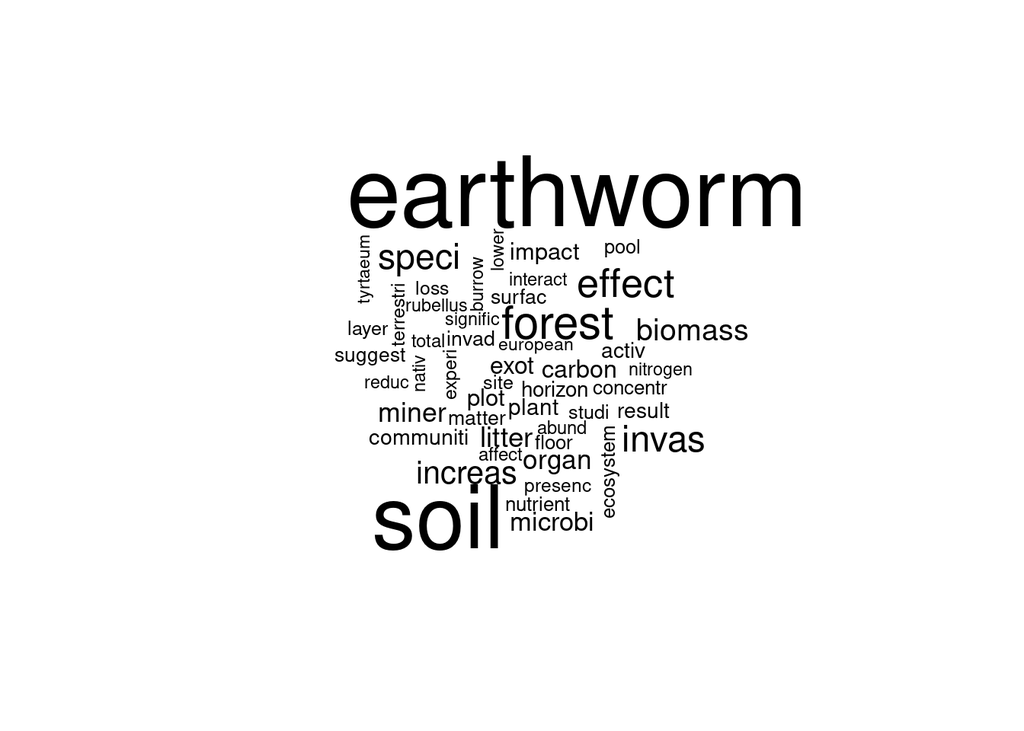

```r
library(wordcloud)
library(dplyr)

unnested_tokens1 %>%
  anti_join(stop_words) %>%
  count(word) %>%
  with(wordcloud(word, n, max.words = 50))
```

```r
cloud1 <- recordPlot()
```

## Wordcloud MA2: “Earthworms affect plant growth and resistance against herbivores: A meta-analysis”

Visuellement, on peut voir sur le nuage de mots que les termes prépondérants dans la MA2 sont : *“plant”,“earthworm”,“aphid”, “soil”*,*“increase”* et *“effect”*. D’autres mots tel que *“community”, “interaction”, “presence”,“affect”* ou *“biomass”* semblent décrire un processus biologique dynamique. La prépondérance de *“plant”* sur les autres semble confirmer que la biologie végétale en lien avec les vers de terre est le thème principal de cette métaanalyse.

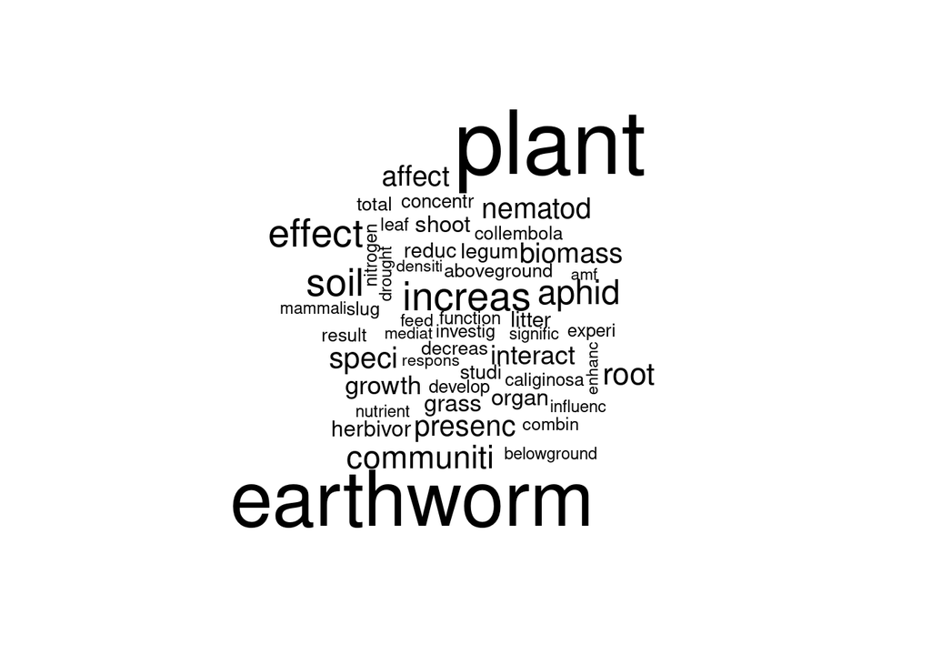

```r
unnested_tokens2 %>%
  anti_join(stop_words) %>%
  count(word) %>%
  with(wordcloud(word, n, max.words = 50))
```

```r
cloud2 <- recordPlot()
```

## Wordcloud MA3: “The unseen invaders: introduced earthworms as drivers of change in plant communities in North American forests (a meta-analysis)”

Visuellement, on peut voir sur le nuage de mots que les termes prépondérants dans la MA3 sont : *“earthworm”,“specie”, “plant”* et *“forest”*. La prépondérance des mots *“earthworm”* et *“specie”* sur les autres semble confirmer que la métaanlyse s’intéresse en particulier à la façon dont les différentes **espèces** de vers de terre (natives ou introduite) influent sur l’écosystème global (et notamment l’écosystème **forestier**). D’autres racines telles que *“invasion”, “community”, “density”, “native”* ou *“increase”* semblent décrire un processus écologique dynamique.

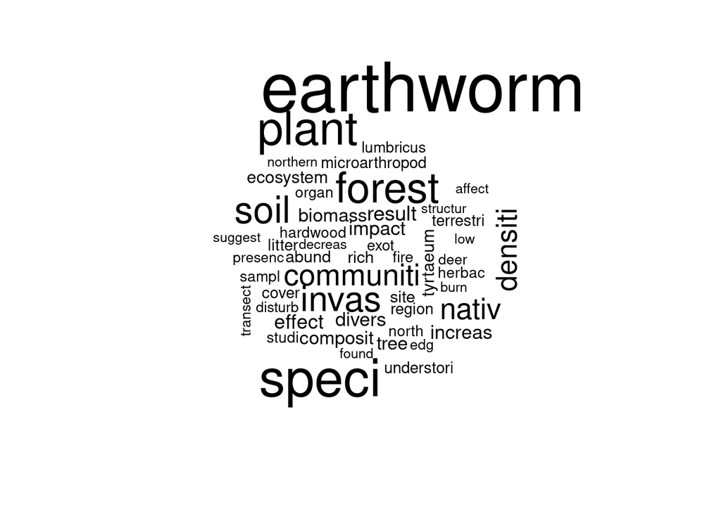

```r
unnested_tokens3 %>%
  anti_join(stop_words) %>%
  count(word) %>%
  with(wordcloud(word, n, max.words = 50))
```

```r
cloud3 <- recordPlot()
```

## Wordcloud MA4: “Earthworms increase plant production: a meta-analysis”

Visuellement, on peut voir sur le nuage de mots que les termes prépondérants dans la MA4 sont : *“earthworm”,“soil”, “plant”*, *“effect”* et *“increase”*. Les mots *“presence”*, *“community”*, *“product”*, *“biomass”* et *“growth”* laissent entendre un effet plutôt positif des vers de terre sur le développement végatal.

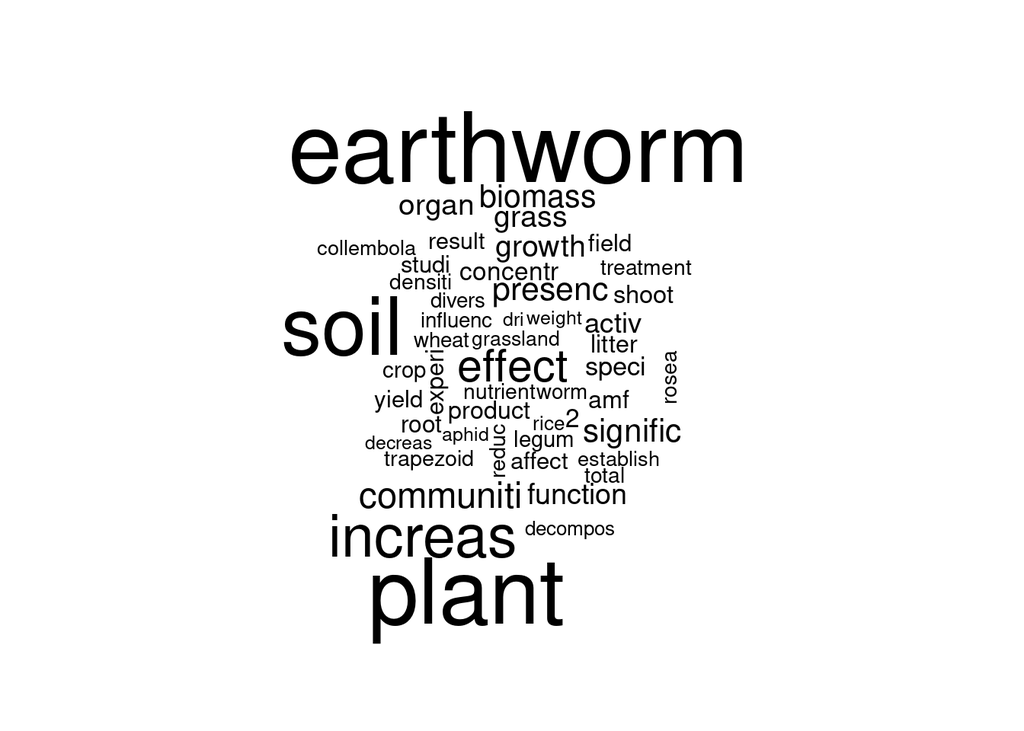

```r
unnested_tokens4 %>%
  anti_join(stop_words) %>%
  count(word) %>%
  with(wordcloud(word, n, max.words = 50))
```

```r
cloud4 <- recordPlot()
```

# Wordcloud: coloration en fonction de la valence des mots (bleu: Positif / rouge: Négatif)

## Wordcloud MA1: “Soil chemistry turned upside down: a meta-analysis of invasive earthworm effects on soil chemical properties”

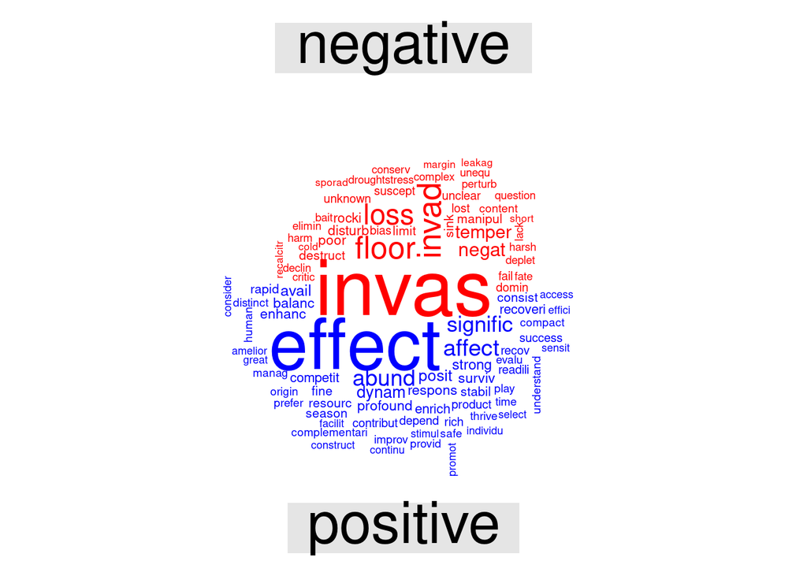

```r
library(reshape2)

unnested_tokens1 %>%
  anti_join(custom_stop_words, by = c("word")) %>%
  inner_join(bingStem) %>%
  count(word, sentiment, sort = TRUE) %>%
  acast(word ~ sentiment, value.var = "n", fill = 0) %>%
  comparison.cloud(colors = c("red", "blue"),
                   max.words = 100)
```

```r
cloud_senti1<-recordPlot()
```

## Wordcloud MA2: “Earthworms affect plant growth and resistance against herbivores: A meta-analysis”

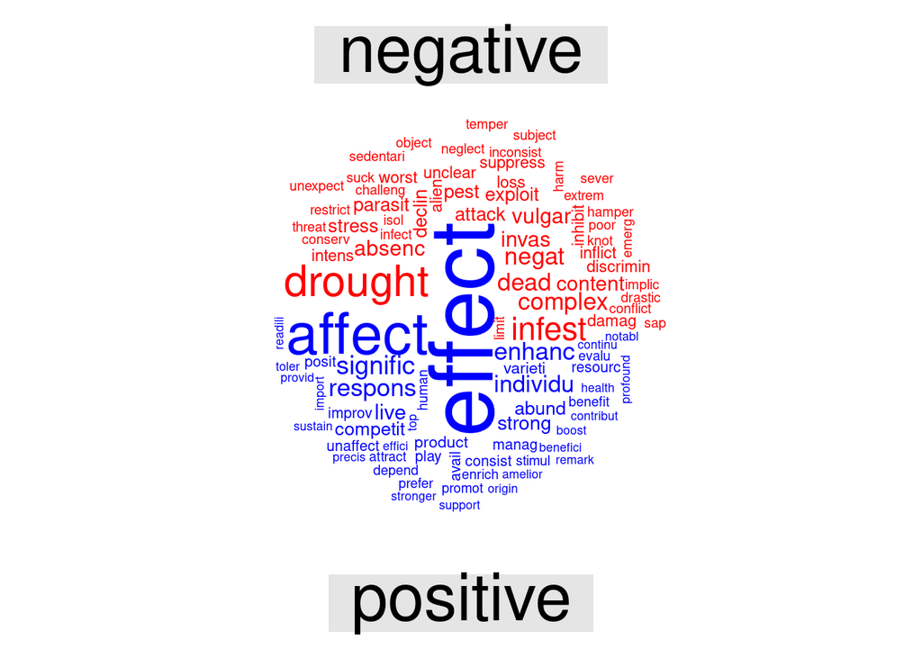

```r
unnested_tokens2 %>%
  anti_join(custom_stop_words, by = c("word")) %>%
  inner_join(bingStem) %>%
  count(word, sentiment, sort = TRUE) %>%
  acast(word ~ sentiment, value.var = "n", fill = 0) %>%
  comparison.cloud(colors = c("red", "blue"),
                   max.words = 100)
```

```r
cloud_senti2<-recordPlot()
```

## Wordcloud MA3: “The unseen invaders: introduced earthworms as drivers of change in plant communities in North American forests (a meta-analysis)”

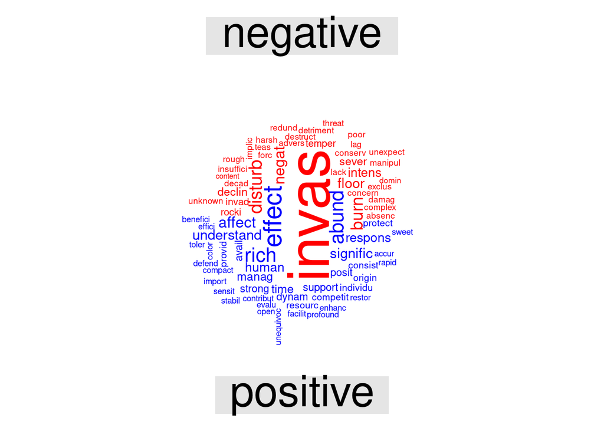

```r
unnested_tokens3 %>%
  anti_join(custom_stop_words, by = c("word")) %>%
  inner_join(bingStem) %>%
  count(word, sentiment, sort = TRUE) %>%
  acast(word ~ sentiment, value.var = "n", fill = 0) %>%
  comparison.cloud(colors = c("red", "blue"),
                   max.words = 100)
```

```r
cloud_senti3<-recordPlot()
```

## Wordcloud MA4: “Earthworms increase plant production: a meta-analysis”

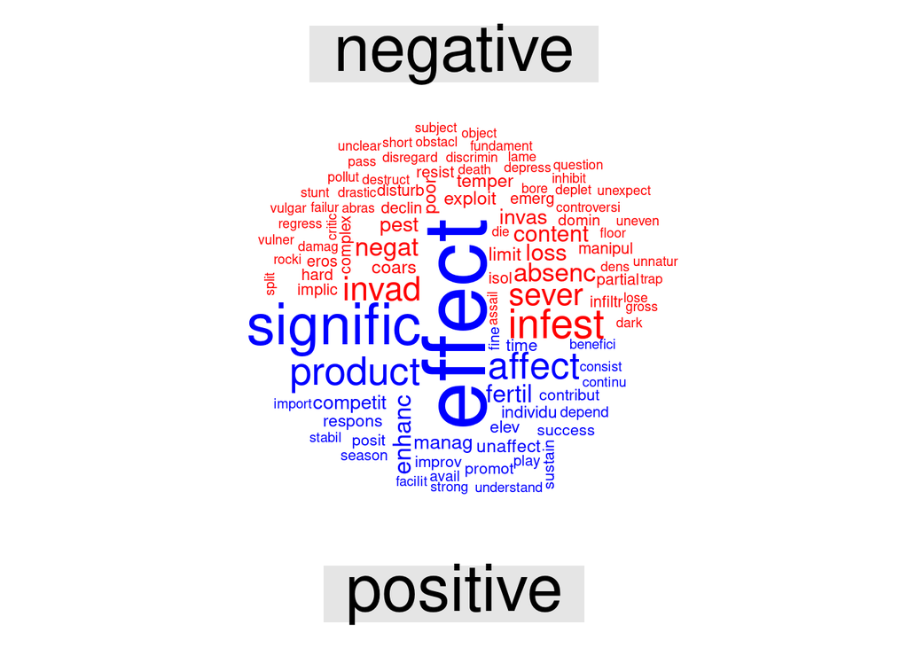

```r
unnested_tokens4 %>%
  anti_join(custom_stop_words, by = c("word")) %>%
  inner_join(bingStem) %>%
  count(word, sentiment, sort = TRUE) %>%
  acast(word ~ sentiment, value.var = "n", fill = 0) %>%
  comparison.cloud(colors = c("red", "blue"),
                   max.words = 100)
```

```r
cloud_senti4<-recordPlot()
```

```r
sentences1 <- tibble(text = abstracts1) %>%
  unnest_tokens(sentence, text, token = "sentences")
sentences2 <- tibble(text = abstracts2) %>%
  unnest_tokens(sentence, text, token = "sentences")
sentences3 <- tibble(text = abstracts3) %>%
  unnest_tokens(sentence, text, token = "sentences")
sentences4 <- tibble(text = abstracts4) %>%
  unnest_tokens(sentence, text, token = "sentences")
```

## Ratios de mots positifs / négatifs pour chaque métaanalyse:

```r
library(dplyr)
library(purrr)
library(kableExtra)

bingnegative <- get_sentiments("bing") %>%
  filter(sentiment == "negative")

bingpositive <- get_sentiments("bing") %>%
  filter(sentiment == "positive")

unnested_tokens1 <- unnested_tokens1 %>%
  mutate(MA = "MA1")
unnested_tokens2 <- unnested_tokens2 %>%
  mutate(MA = "MA2")
unnested_tokens3 <- unnested_tokens3 %>%
  mutate(MA = "MA3")
unnested_tokens4 <- unnested_tokens4 %>%
  mutate(MA = "MA4")

MA_labels <- c("MA1", "MA2", "MA3", "MA4")
word_counts_MA <- c(length(unnested_tokens1$word), length(unnested_tokens2$word), length(unnested_tokens3$word), length(unnested_tokens4$word))

word_count_tibble <- tibble(
  MA = MA_labels,
  words = word_counts_MA
)

all_ratios <- bind_rows(unnested_tokens1,unnested_tokens2,unnested_tokens3,unnested_tokens4)

joined_tibble <- rbind(inner_join(all_ratios, bingnegative, by = "word"),inner_join(all_ratios, bingpositive, by= "word"))
# Assuming joined_tibble is already defined
sentiment_counts <- joined_tibble %>%
    group_by(MA, sentiment) %>%
    summarise(count = n())
# Transpose the summarized counts
sentiment_counts <- sentiment_counts %>%
    pivot_wider(names_from = sentiment, values_from = count)
```

```r
library(dplyr)
library(purrr)
library(kableExtra)

bingnegative <- get_sentiments("bing") %>%
  filter(sentiment == "negative")

bingpositive <- get_sentiments("bing") %>%
  filter(sentiment == "positive")

unnested_tokens1 <- unnested_tokens1 %>%
  mutate(MA = "MA1")
unnested_tokens2 <- unnested_tokens2 %>%
  mutate(MA = "MA2")
unnested_tokens3 <- unnested_tokens3 %>%
  mutate(MA = "MA3")
unnested_tokens4 <- unnested_tokens4 %>%
  mutate(MA = "MA4")

MA_labels <- c("MA1", "MA2", "MA3", "MA4")
word_counts_MA <- c(length(unnested_tokens1$word), length(unnested_tokens2$word), length(unnested_tokens3$word), length(unnested_tokens4$word))

word_count_tibble <- tibble(
  MA = MA_labels,
  words = word_counts_MA
)

all_ratios <- bind_rows(unnested_tokens1,unnested_tokens2,unnested_tokens3,unnested_tokens4)

joined_tibble <- rbind(inner_join(all_ratios, bingnegative, by = "word"),inner_join(all_ratios, bingpositive, by= "word"))

MA_titles <- c("Soil chemistry turned upside down: a meta-analysis [...]","Earthworms affect plant growth and resistance [...]","The unseen invaders: [...] in north American forests (a meta-analysis)","Earthworms increase plant production: a meta-analysis")

positive_count=c(sentiment_counts$positive[1], sentiment_counts$positive[2], sentiment_counts$positive[3], sentiment_counts$positive[4])
negative_count=c(sentiment_counts$negative[1], sentiment_counts$negative[2], sentiment_counts$negative[3], sentiment_counts$negative[4])

summary_tibble <- joined_tibble %>%
  group_by(MA) %>%
  summarize(
    positivewords = positive_count,
    negativewords = negative_count,
    sentimentwords=positive_count + negative_count
  ) %>%
  left_join(word_count_tibble, by = "MA") %>%
  mutate(positive_ratio = signif(positivewords / sentimentwords,digits = 2)) %>%
  mutate(negative_ratio = signif(negativewords / sentimentwords,digits = 2))

summary_tibble <- data.frame(
    MA = unique(summary_tibble$MA),
    positivewords = unique(summary_tibble$positivewords),
    negativewords = unique(summary_tibble$negativewords),
    words = unique(summary_tibble$sentimentwords),
    positive_ratio = unique(summary_tibble$positive_ratio),
    negative_ratio = unique(summary_tibble$negative_ratio)
) %>%head(4)

summary_tibble <- as_tibble(summary_tibble)

summary_tibble %>%
  mutate(MA_title = MA_titles) %>%
  mutate(current_MA = MA) %>%
  select(MA_title, current_MA, words, positivewords, negativewords, positive_ratio, negative_ratio)
```

```
## # A tibble: 4 × 7
##   MA_title           current_MA words positivewords negativewords positive_ratio
##   <chr>              <chr>      <int>         <int>         <int>          <dbl>
## 1 Soil chemistry tu… MA1          231            82           149           0.35
## 2 Earthworms affect… MA2          115            24            91           0.21
## 3 The unseen invade… MA3           68            30            38           0.44
## 4 Earthworms increa… MA4          138            56            82           0.41
## # ℹ 1 more variable: negative_ratio <dbl>
```

```r
 summary_tibble %>%
  kbl() %>%
  kable_material_dark("hover", full_width = F) %>%
  row_spec(0, bold = T, color = "black", background = "#D7261E")
```

| MA | positivewords | negativewords | words | positive_ratio | negative_ratio |
| --- | --- | --- | --- | --- | --- |
| MA1 | 82 | 149 | 231 | 0.35 | 0.65 |
| MA2 | 24 | 91 | 115 | 0.21 | 0.79 |
| MA3 | 30 | 38 | 68 | 0.44 | 0.56 |
| MA4 | 56 | 82 | 138 | 0.41 | 0.59 |

Le tablau ci-dessus présente, pour chaque MA, le rapport mot positifs / total sentiment (colonne “positive ratio”) et le le rapport mot négatifs / total sentiment (colonne “negative ratio”). On peut donc classer les MA dans cet ordre, la plus positive en dernier: MA2, MA1, MA4, MA3. On peut donc écrire, de manière synthétique, que:  
* **MA1:** 35% des mots connotés sont positifs, 65% sont négatifs.  
* **MA2:** 21% des mots connotés sont positifs, 79% sont négatifs.  
* **MA3:** 44% des mots connotés sont positifs, 56% sont négatifs.  
* **MA4:** 41% des mots connotés sont positifs, 59% sont négatifs.  
Ces ratios semblent plutôt surprenants, car des métaanalyses au titre paraissant plutôt négatif (comme la MA3), ont finalement le ratio de mots positifs le plus élévé des quatre. A l’inverse, la MA2 semble être la plus négative alors que son titre paraît plutôt optimiste. Une analyse plus approfondie des textes permettrait probablement de résoudre cet apparent paradoxe.  
Cependant, le ratio de mots négatifs est dans tous les cas > 50%, ce qui semble indiquer que la vision du vers de terre présentée dans ces articles est majoritairement négative.

MA1: “Soil chemistry turned upside down: a meta-analysis of invasive earthworm effects on soil chemical properties”  
MA2: “Earthworms affect plant growth and resistance against herbivores: A meta-analysis”  
MA3: “The unseen invaders: introduced earthworms as drivers of change in plant communities in North American forests (a meta-analysis)”  
MA4: “Earthworms increase plant production: a meta-analysis”

# Approche tf-idf :

**Définitions:**  
*tf*: term frequency.  
*idf*: inverse document frequency. Plus élaboré que l’approche en “stop words”. Diminue la fréquence des termes rencontrés très souvent et augmente la fréquence des termes rares, en jouant sur la pondération.  
*tf-idf*: le produit de ces deux indices. Il premet d’identifier les mots qui sont **plus importants pour un document spécifique** parmi un ensemble de documents.

```r
unnested_tokens1 <- tibble(abstracts1) %>%
mutate(MA="MA1") %>%
unnest_tokens(word, abstracts1)
unnested_tokens1<-unnested_tokens1 %>% rowwise() %>% mutate(word = wordStem(word, language = "en"))

unnested_tokens2 <- tibble(abstracts2) %>%
  mutate(MA="MA2") %>%
  unnest_tokens(word, abstracts2)
unnested_tokens2 <- unnested_tokens2 %>% rowwise() %>% mutate(word = wordStem(word, language = "en"))

unnested_tokens3 <- tibble(abstracts3) %>%
  mutate(MA="MA3") %>%
  unnest_tokens(word, abstracts3)
unnested_tokens3 <- unnested_tokens3 %>% rowwise() %>% mutate(word = wordStem(word, language = "en"))

unnested_tokens4 <- tibble(abstracts4) %>%
  mutate(MA="MA4") %>%
  unnest_tokens(word, abstracts4)
unnested_tokens4 <- unnested_tokens4 %>% rowwise() %>% mutate(word = wordStem(word, language = "en"))
```

```r
word_counts_MA <- c(length(unnested_tokens1$word), length(unnested_tokens2$word), length(unnested_tokens3$word),length(unnested_tokens4$word))

ordre1=unnested_tokens1 %>%
     count(word, sort = TRUE) %>%
     mutate(word = reorder(word, n,decreasing=TRUE))
tokens_ordered_1 <- left_join(unnested_tokens1, ordre1) %>%
  mutate(Total=word_count_tibble$words[1])

ordre2=unnested_tokens2 %>%
     count(word, sort = TRUE) %>%
     mutate(word = reorder(word, n,decreasing=TRUE))
tokens_ordered_2 <- left_join(unnested_tokens2, ordre2) %>%
  mutate(Total=word_count_tibble$words[2])

ordre3=unnested_tokens4 %>%
     count(word, sort = TRUE) %>%
     mutate(word = reorder(word, n,decreasing=TRUE))
tokens_ordered_3 <- inner_join(unnested_tokens3, ordre3) %>%
  mutate(Total=word_count_tibble$words[3])

ordre4=unnested_tokens4 %>%
     count(word, sort = TRUE) %>%
     mutate(word = reorder(word, n,decreasing=TRUE))
tokens_ordered_4 <- left_join(unnested_tokens4, ordre4) %>%
  mutate(Total=word_count_tibble$words[4])

all_freq <- bind_rows(tokens_ordered_1,tokens_ordered_2,tokens_ordered_3,tokens_ordered_4) %>% mutate(word_frequency = n/Total)
```

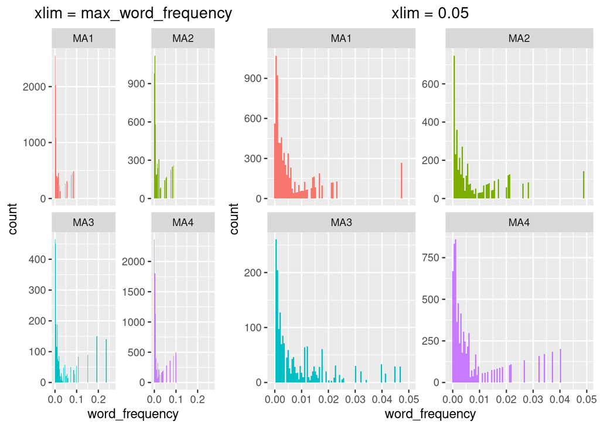

```r
library(ggplot2)
library(egg)

word_freq_plot1 <- ggplot(all_freq, aes(x = word_frequency, fill = MA)) +
  geom_histogram(bins=100,show.legend = FALSE) +
  ggtitle("xlim = max_word_frequency") +
  theme(plot.title = element_text(hjust = 0.5)) +
  xlim(NA, max(all_freq$word_frequency)) +
  facet_wrap(~MA, ncol = 2, scales = "free_y")

word_freq_plot2 <-ggplot(all_freq, aes(x = word_frequency, fill = MA)) +
  geom_histogram(bins=100,show.legend = FALSE) +
  ggtitle("xlim = 0.05") +
  theme(plot.title = element_text(hjust = 0.5)) +
  xlim(NA, 0.05) +
  facet_wrap(~MA, ncol = 2, scales = "free_y")

ggarrange(word_freq_plot1,word_freq_plot2,widths = c(1,2))
```

Ces graphiques présentent des distributions proches pour toutes les MA, avec de nombreux mots qui apparaissent rarement et moins de mots qui apparaissent fréquemment (le premier groupe de 4 graphes représentant l’intégralité des données, le deuxième groupe de 4 se focalisant uniquement sur l’intervalle [0;0.05], pour inspecter le massif de pics davantage en détail). En x, on peut voir que les mots apparaissant très souvent (à droite) sont rares, alors que les mots qui apparaissent peu souvent (à gauche) sont fréquents. Ces graphiques présentent des distributions similaires pour toutes les MA, avec de nombreux mots qui apparaissent rarement et moins de mots qui apparaissent fréquemment.

## Loi de Zipf:

La loi de Zipf, découverte empiriquement par Zipf (1949) pour des mots d’un corpus anglais, stipule que si *f* est la fréquence d’un mot dans le corpus et *r* le rang, alors :  
$frequency \propto \frac{1}{rank}$  
(la fréquence d’un mot donné est inversement proportionnelle à son rang).

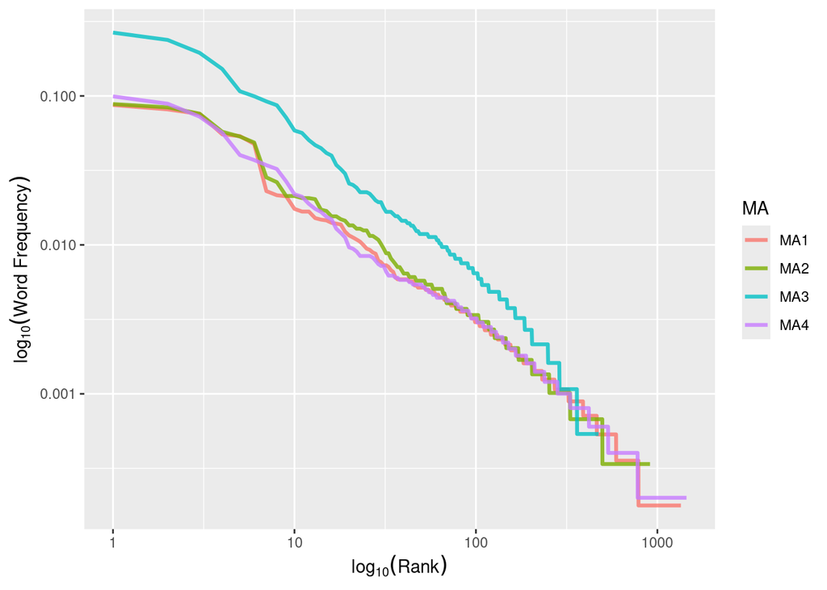

```r
library(latex2exp)

freq_and_rank <-  all_freq %>% group_by(MA) %>%
    distinct(word, .keep_all = TRUE) %>%
    arrange(desc(n)) %>%
    mutate(rank = seq_len(length(word)), word_frequency = n/Total) %>% #
    ungroup()

freq_and_rank %>%
    ggplot(aes(rank, word_frequency, color = MA)) +
    geom_line(linewidth = 1.1, alpha = 0.8, show.legend = TRUE) +
    scale_x_log10() +
    scale_y_log10() +
  xlab(TeX("$\\log_{10}(Rank)$")) +
  ylab(TeX("$\\log_{10}(Word~Frequency)$"))
```

Les courbes de Zipf (log10(f) contre log10(r)) obtenues ci-dessus ont une pente négative. On peut visualiser graphiquement qu’il existe bel et bien une relation inversement proportionnelle entre *f* et *r* (échelle logarithmique). On peut cependant remarquer que la décroissance observée n’est pas strictement monotone. On pourrait considérer ces courbes comme des lois de puissance brisées (fonction par morceaux donnée par une séquence de lois de puissance jointes où chaque section a sa propre puissance (indice) et est définie par des “ruptures” limitatives.) et les diviser en trois sections: [1;10]/[10;100]/[100;1000]. Voyons quel est l’exposant de la loi de puissance pour la partie centrale de la plage de rangs.

```r
rank_subset <- freq_and_rank %>%
  filter(rank < 100,
         rank > 10)
lm(log10(word_frequency) ~ log10(rank), data = rank_subset)
```

[output not shown]

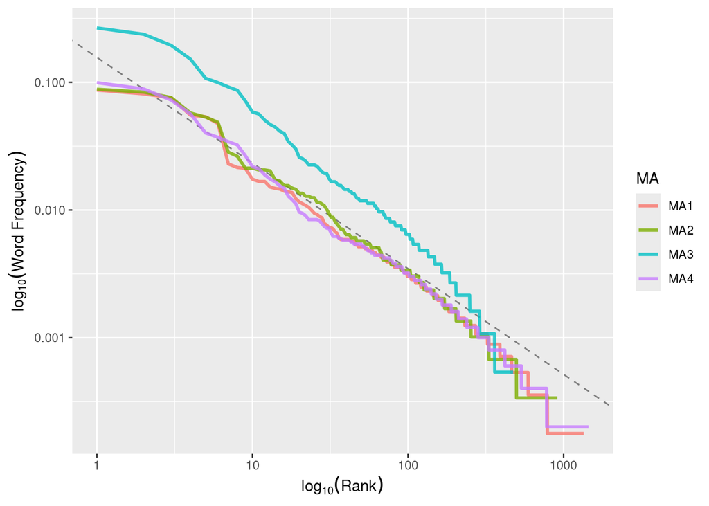

```r
library(latex2exp)

freq_and_rank %>% ggplot(aes(rank, word_frequency, color = MA)) +
  geom_abline(intercept = -0.8048, slope = -0.8272,
              color = "gray50", linetype = 2) +
  geom_line(linewidth = 1.1, alpha = 0.8, show.legend = TRUE) +
  scale_x_log10() +
  scale_y_log10() +
  xlab(TeX("$\\log_{10}(Rank)$")) +
  ylab(TeX("$\\log_{10}(Word~Frequency)$"))
```

```r
word_count_tibble%>%
  kbl() %>%
  kable_material_dark("hover", full_width = F) %>%
  row_spec(0, bold = T, color = "black", background = "#D7261E")
```

| MA | words |
| --- | --- |
| MA1 | 5616 |
| MA2 | 2959 |
| MA3 | 1860 |
| MA4 | 4985 |

## Fonction bind_tf_idf:

```r
MA_tf_idf <- all_freq %>%
  distinct(word, .keep_all = TRUE) %>%
  select(-word_frequency) %>%
  select(-Total) %>%
  bind_tf_idf(word, MA, n) %>%
  arrange(desc(tf_idf))

MA_tf_idf
```

```
## # A tibble: 2,221 × 6
## # Rowwise:
##    MA    word       n     tf   idf tf_idf
##    <chr> <chr>  <int>  <dbl> <dbl>  <dbl>
##  1 MA3   requir     4 0.133   1.39 0.185
##  2 MA3   k          4 0.133   1.39 0.185
##  3 MA3   april      2 0.0667  1.39 0.0924
##  4 MA3   everi      2 0.0667  1.39 0.0924
##  5 MA3   19         2 0.0667  1.39 0.0924
##  6 MA3   open       2 0.0667  1.39 0.0924
##  7 MA3   na         2 0.0667  1.39 0.0924
##  8 MA2   aphid     50 0.0540  1.39 0.0749
##  9 MA1   the      488 0.0494  1.39 0.0685
## 10 MA1   and      456 0.0462  1.39 0.0640
## # ℹ 2,211 more rows
```

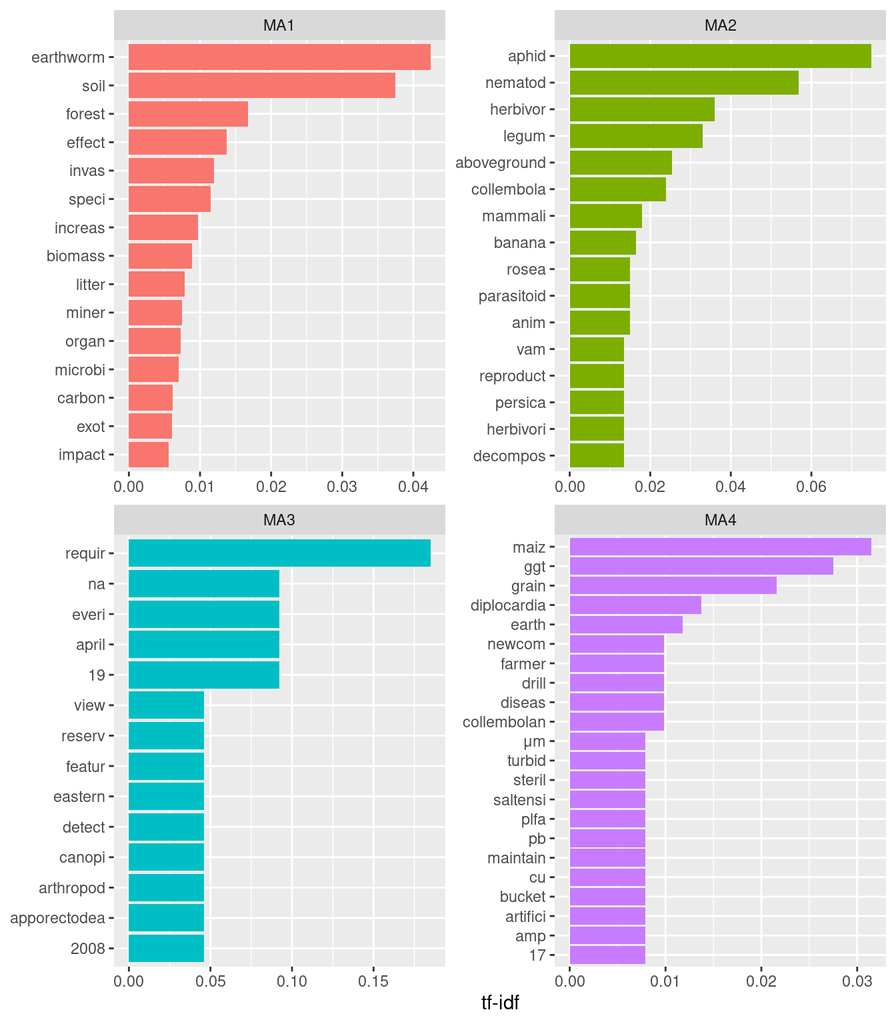

```r
library(forcats)

MA_tf_idf %>%
  anti_join(stop_words) %>%
  anti_join(custom_stop_words) %>%
  group_by(MA) %>%
  slice_max(tf_idf, n = 15) %>%
  ungroup() %>%
  ggplot(aes(tf_idf, fct_reorder(word, tf_idf), fill = MA)) +
  geom_col(show.legend = FALSE) +
  facet_wrap(~MA, ncol = 2, scales = "free") +
  labs(x = "tf-idf", y = NULL)
```

Rappelons les suppositions faites précédemment dans la partie “Analyse de sentiment”:  
- **MA1/MA3:** étude de l’impact écologique des vers de terre sur les écosystèmes.  
- **MA2:** étude des effets des vers de terre sur la physiologie végétale.  
- **MA4:** étude de l’influence des vers de terre invasifs sur la production végétale.

MA1: “Soil chemistry turned upside down: a meta-analysis of invasive earthworm effects on soil chemical properties”  
MA2: “Earthworms affect plant growth and resistance against herbivores: A meta-analysis”  
MA3: “The unseen invaders: introduced earthworms as drivers of change in plant communities in North American forests (a meta-analysis)”  
MA4: “Earthworms increase plant production: a meta-analysis”

## n-grams et corrélations :

```r
library(dplyr)
library(tidytext)

all_abstracts_df <- rbind(data.frame(abstract = abstracts1, MA = "MA1"),
      data.frame(abstract = abstracts2, MA = "MA2"),
      data.frame(abstract = abstracts3, MA = "MA3"),
      data.frame(abstract = abstracts4, MA = "MA4"))

tokens_bigrams_all <- tibble(all_abstracts_df) %>%
  unnest_tokens(bigram, abstract, token = "ngrams", n = 2) %>%
  filter(!is.na(bigram))

tokens_bigrams1 <- tibble(abstracts1) %>%
  unnest_tokens(bigram, abstracts1, token = "ngrams", n = 2) %>%
  filter(!is.na(bigram))

tokens_bigrams2 <- tibble(abstracts2) %>%
  unnest_tokens(bigram, abstracts2, token = "ngrams", n = 2) %>%
  filter(!is.na(bigram))

tokens_bigrams3 <- tibble(abstracts3) %>%
  unnest_tokens(bigram, abstracts3, token = "ngrams", n = 2) %>%
  filter(!is.na(bigram))

tokens_bigrams4 <- tibble(abstracts4) %>%
  unnest_tokens(bigram, abstracts4, token = "ngrams", n = 2) %>%
  filter(!is.na(bigram))

tokens_bigrams1 %>% count(bigram, sort = TRUE)
```

```
## # A tibble: 6,279 × 2
##    bigram                 n
##    <chr>              <int>
##  1 in the                81
##  2 of the                73
##  3 effects of            31
##  4 microbial biomass     31
##  5 organic matter        29
##  6 of earthworm          26
##  7 of earthworms         26
##  8 earthworm invasion    25
##  9 forest floor          25
## 10 c and                 24
## # ℹ 6,269 more rows
```

```r
tokens_bigrams2 %>%
 count(bigram, sort = TRUE)
```

```
## # A tibble: 3,564 × 2
##    bigram            n
##    <chr>         <int>
##  1 in the           35
##  2 of earthworms    34
##  3 effects of       31
##  4 presence of      31
##  5 the presence     30
##  6 of the           28
##  7 on the           18
##  8 plant species    17
##  9 plant growth     16
## 10 affected by      15
## # ℹ 3,554 more rows
```

```r
tokens_bigrams3 %>%
 count(bigram, sort = TRUE)
```

```
## # A tibble: 2,448 × 2
##    bigram                n
##    <chr>             <int>
##  1 of the               19
##  2 in the               16
##  3 non native           15
##  4 plant species        15
##  5 native plant         14
##  6 earthworm species    11
##  7 of earthworm         11
##  8 and the              10
##  9 o tyrtaeum           10
## 10 changes in            9
## # ℹ 2,438 more rows
```

```r
tokens_bigrams4 %>%
 count(bigram, sort = TRUE)
```

```
## # A tibble: 6,044 × 2
##    bigram              n
##    <chr>           <int>
##  1 in the             80
##  2 of the             64
##  3 presence of        43
##  4 the presence       41
##  5 of earthworms      34
##  6 on the             28
##  7 the soil           27
##  8 plant community    26
##  9 effects of         25
## 10 in a               23
## # ℹ 6,034 more rows
```

De nombreux bigrammes sont non-informatifs (“in the”, “of the” etc.). On va donc réemployer l’approche en “stop words” des étapes précédentes pour enlever ces mots.

```r
# bigrams ok, separated ok,  filtered ok.
bigrams_separated_all <- tokens_bigrams_all %>%
  separate(bigram, c("word1", "word2"), sep = " ")

bigrams_separated1 <- tokens_bigrams1 %>%
  separate(bigram, c("word1", "word2"), sep = " ")

bigrams_filtered_all <- bigrams_separated_all %>%
  filter(!word1 %in% combined_stop_words$word) %>%
  filter(!word2 %in% combined_stop_words$word)

bigrams_filtered1 <- bigrams_separated1 %>%
  filter(!word1 %in% combined_stop_words$word) %>%
  filter(!word2 %in% combined_stop_words$word)

# new bigram counts:
bigram_counts_all <- bigrams_filtered_all %>%
  count(MA, word1, word2, sort = TRUE)

bigram_counts1 <- bigrams_filtered1 %>%
  count(word1, word2, sort = TRUE)

# For bigrams_2
bigrams_separated2 <- tokens_bigrams2 %>%
  separate(bigram, c("word1", "word2"), sep = " ")

bigrams_filtered2 <- bigrams_separated2 %>%
  filter(!word1 %in% combined_stop_words$word) %>%
  filter(!word2 %in% combined_stop_words$word)

bigram_counts2 <- bigrams_filtered2 %>%
  count(word1, word2, sort = TRUE)

# For bigrams_3
bigrams_separated3 <- tokens_bigrams3 %>%
  separate(bigram, c("word1", "word2"), sep = " ")

bigrams_filtered3 <- bigrams_separated3 %>%
  filter(!word1 %in% combined_stop_words$word) %>%
  filter(!word2 %in% combined_stop_words$word)

bigram_counts3 <- bigrams_filtered3 %>%
  count(word1, word2, sort = TRUE)

# For bigrams_4
bigrams_separated4 <- tokens_bigrams4 %>%
  separate(bigram, c("word1", "word2"), sep = " ")

bigrams_filtered4 <- bigrams_separated4 %>%
  filter(!word1 %in% combined_stop_words$word) %>%
  filter(!word2 %in% combined_stop_words$word)

bigram_counts4 <- bigrams_filtered4 %>%
  count(word1, word2, sort = TRUE)

bigrams_united_all <- bigrams_filtered_all %>%
  unite(bigram, word1, word2, sep = " ")

bigrams_united_all %>% count(MA, bigram, sort = TRUE)
```

```
## # A tibble: 5,506 × 3
##    MA    bigram                 n
##    <chr> <chr>              <int>
##  1 MA1   microbial biomass     31
##  2 MA1   organic matter        29
##  3 MA4   plant community       26
##  4 MA1   earthworm invasion    25
##  5 MA1   forest floor          25
##  6 MA1   exotic earthworms     24
##  7 MA1   mineral soil          23
##  8 MA1   earthworm species     18
##  9 MA2   plant species         17
## 10 MA4   plant growth          17
## # ℹ 5,496 more rows
```

```r
earthworms_bigrams <- bigrams_united_all %>%
    filter(grepl("earthworms?", bigram, ignore.case = TRUE))
# Count occurrences of MA and word2 combination, sorted in descending order
count_earthworm_bigrams<- earthworms_bigrams %>%
    count(MA, bigram, sort = TRUE) %>%
    group_by(MA) %>%
    filter(n>5) %>%
    mutate(MA = factor(MA, levels = c("MA1", "MA2", "MA3", "MA4"))) %>% # Set the order of MA
    arrange(MA, desc(n)) # Sort by MA and then by n in descending order
count_earthworm_bigrams
```

```
## # A tibble: 22 × 3
## # Groups:   MA [4]
##    MA    bigram                   n
##    <fct> <chr>                <int>
##  1 MA1   earthworm invasion      25
##  2 MA1   exotic earthworms       24
##  3 MA1   earthworm species       18
##  4 MA1   earthworm activity       9
##  5 MA1   earthworm biomass        8
##  6 MA1   earthworm invaded        7
##  7 MA1   european earthworms      7
##  8 MA1   exotic earthworm         7
##  9 MA1   earthworm community      6
## 10 MA2   earthworms increased     7
## # ℹ 12 more rows
```

```r
library(dplyr)

# Define the function
count_filtered_bigrams <- function(data, regex_motif,treshold) {
  # Filter the bigrams based on the provided regex motif
  filtered_bigrams <- data %>%
    filter(grepl(regex_motif, bigram, ignore.case = TRUE))

  # Count occurrences of each combination of `MA` and `bigram`, sort in descending order,
  # group by `MA`, and filter counts greater than 5 within each group
  count_bigrams <- filtered_bigrams %>%
    count(MA, bigram, sort = TRUE) %>%
    group_by(MA) %>%
    filter(n > treshold) %>%
    mutate(MA = factor(MA, levels = c("MA1", "MA2", "MA3", "MA4"))) %>%
    arrange(MA, desc(n)) # Sort by MA and then by n in descending order

  return(count_bigrams)
}

count_filtered_bigrams(bigrams_united_all,"earthworms?",5)
```

```
## # A tibble: 22 × 3
## # Groups:   MA [4]
##    MA    bigram                   n
##    <fct> <chr>                <int>
##  1 MA1   earthworm invasion      25
##  2 MA1   exotic earthworms       24
##  3 MA1   earthworm species       18
##  4 MA1   earthworm activity       9
##  5 MA1   earthworm biomass        8
##  6 MA1   earthworm invaded        7
##  7 MA1   european earthworms      7
##  8 MA1   exotic earthworm         7
##  9 MA1   earthworm community      6
## 10 MA2   earthworms increased     7
## # ℹ 12 more rows
```

```r
count_filtered_bigrams(bigrams_united_all,"invasions?",5)
```

```
## # A tibble: 3 × 3
## # Groups:   MA [2]
##   MA    bigram                  n
##   <fct> <chr>               <int>
## 1 MA1   earthworm invasion     25
## 2 MA3   earthworm invasion      7
## 3 MA3   earthworm invasions     6
```

```r
count_filtered_bigrams(bigrams_united_all,"invaders?",0)
```

```
## # A tibble: 9 × 3
## # Groups:   MA [2]
##   MA    bigram                 n
##   <fct> <chr>              <int>
## 1 MA1   earthworm invaders     1
## 2 MA1   invaders affect        1
## 3 MA4   invader plants         2
## 4 MA4   invader species        2
## 5 MA4   plant invader          2
## 6 MA4   invader biomass        1
## 7 MA4   invader seed           1
## 8 MA4   invader treatments     1
## 9 MA4   plant invaders         1
```

```r
count_filtered_bigrams(bigrams_united_all,"europeans?",0)
```

```
## # A tibble: 23 × 3
## # Groups:   MA [4]
##    MA    bigram                  n
##    <fct> <chr>               <int>
##  1 MA1   european earthworms     7
##  2 MA1   european species        5
##  3 MA1   european earthworm      4
##  4 MA1   european settlers       2
##  5 MA1   introduced european     2
##  6 MA1   invasive european       2
##  7 MA1   european lumbricids     1
##  8 MA1   exotic european         1
##  9 MA1   processes european      1
## 10 MA1   time european           1
## # ℹ 13 more rows
```

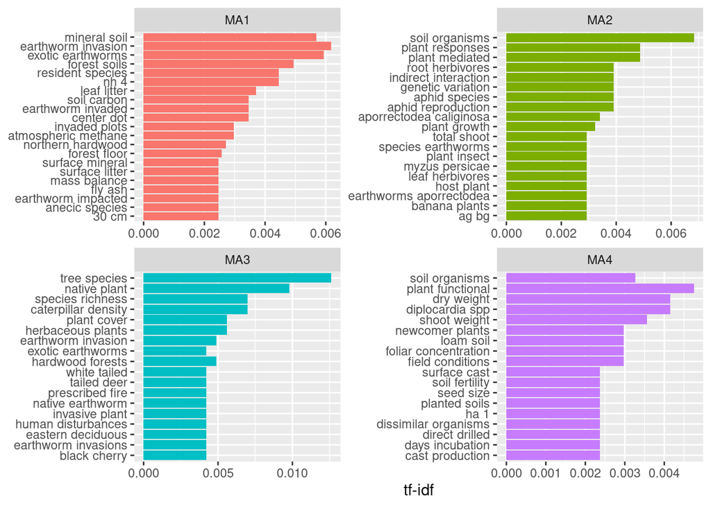

```r
bigram_tf_idf <- bigrams_united_all %>%
  count(MA, bigram) %>%
  bind_tf_idf(bigram, MA, n) %>%
  arrange(desc(tf_idf))

bigram_tf_idf %>%
    group_by(MA) %>%
    slice_max(tf_idf, n = 15) %>%
    ungroup() %>%
    ggplot(aes(tf_idf, fct_reorder(bigram, tf_idf), fill = MA)) +
    geom_col(show.legend = FALSE) +
    facet_wrap(~MA, ncol = 2, scales = "free") +
    labs(x = "tf-idf", y = NULL)
```

D’après les graphiques ci-dessus, on peut constater que:  
Les bigrammes *“mineral soil”*, *“earthworm invasion”*, *“exotic earthworms”* et *“forest soils”* sont plus souvent employés dans la MA1 que dans les autres MA. Le bigramme *“earthworm invaded”* est aussi plus présent dans la MA1 que dans les autres MA.  
Les bigrammes *“soil organisms”*, *“plant responses”*, *“plant mediated”* et *“root herbivore”* sont plus souvent employés dans la MA2 que dans les autres MA. Le bigramme *“aphid species”* est aussi plus présent dans la MA2 que dans les autres MA.  
Les bigrammes *“tree species”*, *“native plant”*, *“species richness”* et *“caterpillar density”* sont plus souvent employés dans la MA3 que dans les autres MA. Le bigramme *“earthworm invasions”* est aussi plus présent dans la MA3 que dans les autres MA.  
Les bigrammes *“soil organisms”*, *“plant functionnal”*, *“dry weight”* et *“diplocardia spp”* sont plus souvent employés dans la MA4 que dans les autres MA. Le bigramme *“soil fertility”* est aussi plus présent dans la MA4 que dans les autres MA.

Rappelons les suppositions faites dans la section précédente:  
- La MA1 se focalise plus que les autres sur l’impact écologique des vers de terre sur les forêts, sous la modalité d’une **“invasion”** biologique.  
- La MA2 se focalise plus que les autres sur les organismes herbivores comme les pucerons (“aphids”). Le mot **“parasitoid”** laisse entendre un effet parasitaire des pucerons sur les végétaux. Cela semble cohérent avec les résultats obtenus précédemment (voir “Analyse de sentiment” et “Wordcloud: coloration en fonction de la valence des mots”). D’après le titre de la métaanalyse, les vers de terre semblent par contre avoir une influence positive sur la résistance des plantes aux pucerons (id.).  
- La MA3 se focalise plus que les autres sur les effets des vers de terre sur les forêts (d’après le titre et le mot-clé *“canopy”*), et sur les aggrégats, peut-être chimiques ou biochimiques, présents dans le sol.  
- La MA4 se focalise plus que les autres sur les effets des vers de terre sur la production végétale (comme semble l’indiquer le mot PLFA (acides gras phospholipidiques), un marqueur de la biomasse vivante), d’après le titre de la métaanalyse et le champs lexical abondant en lien avec le monde agricole (*“maize”*, *“grain”*, *“herbivore”*,*“harvest”*, *“fertilizer”*, *“farmer”* et *“pb”*). Le terme **“Pb”** semble indiquer que la métanalyse s’intéresse probablement aux conséquences écosystémiques des métaux lourds présents dans le sol.

En prenant en compte le sujet apparent de chaque métaanalyse, on peut supposer que:  
- La MA1 se focalise plus que les autres sur l’impact écologique des vers de terre **“exotiques”** sur l’écosystème du **sol** forestier, sous la modalité d’une **“invasion”** biologique.  
- La MA2 se focalise plus que les autres sur l’effet des **“organismes du sol”**, et plus précisément ceux affectant les **“racines”**, sur les plantes, en observant notamment, probablement, les stratégies d’adaptation des plante face à cette source de stress biotique (*“plant responses”*). Les **“espèces de pucerons”** semblent particulièrement ciblées comme étant la source de ce stress.  
- La MA3 se focalise plus que les autres sur l’impact écologique (*“species richness”, “caterpillar density”,“tree species”,“native plants”*) des vers de terre invasifs (*“earthworm invasions”*) sur les forêts d’Amérique du nord. Le champ lexical de la richesse spécifique et de la diversité, ainsi que le wordlcoud de la partie “Wordcloud: coloration en fonction de la valence des mots (bleu: Positif / rouge: Négatif)”, semble évoquer un *“déclin”*, un *“dommage”*, une *“destruction”*. On peut donc en conclure que dans cette MA, les vers de terre invasifs sont dépeints comme des nuisibles majeurs contre l’écosystème natif nord américain.  
- La MA4 se focalise plus que les autres sur les effets des vers de terre et des **organismes du sol** sur la production (*“dry weight”*) et la physiologie végétale (*“plant functionnal”*). Elle s’intéresse aussi à la **fertilité des sol**, ce qui semble cohérent avec le champ lexical agricole relevé plus tôt (*“maize”*, *“grain”*, *“herbivore”*,*“harvest”*, *“fertilizer”*, *“farmer”* et *“pb”*). Le terme **“Pb”** semble indiquer que la métanalyse s’intéresse probablement aux conséquences écosystémiques des métaux lourds présents dans le sol.

MA1: “Soil chemistry turned upside down: a meta-analysis of invasive earthworm effects on soil chemical properties”  
MA2: “Earthworms affect plant growth and resistance against herbivores: A meta-analysis”  
MA3: “The unseen invaders: introduced earthworms as drivers of change in plant communities in North American forests (a meta-analysis)”  
MA4: “Earthworms increase plant production: a meta-analysis”

## n-grams et analyse de sentiment:

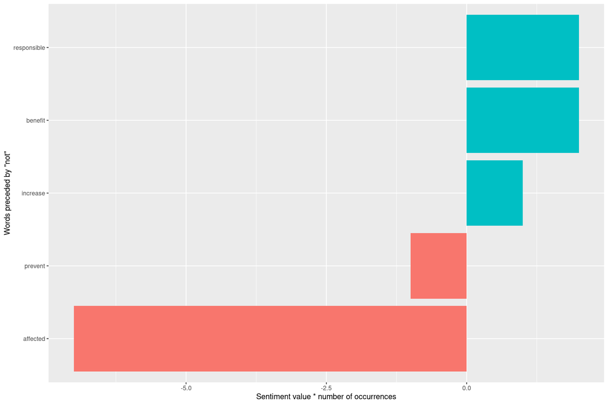

```r
 library(ggplot2)

AFINN <-get_sentiments("afinn")

not_words <- bigrams_separated_all %>%
  filter(word1 == "not") %>%
  inner_join(AFINN, by = c(word2 = "word")) %>%
  count(word2, value, sort = TRUE)

not_words %>%
  mutate(contribution = n * value) %>%
  arrange(desc(abs(contribution))) %>%
  mutate(word2 = reorder(word2, contribution)) %>%
  ggplot(aes(contribution, word2, fill = contribution > 0)) +
  geom_col(show.legend = FALSE) +
  labs(x = "Sentiment value * number of occurrences",
       y = "Words preceded by \"not\"")
```

```r
library(ggplot2)

AFINN <-get_sentiments("afinn")
bigrams_separated1 %>%
  filter(word1 == "not") %>%
  inner_join(AFINN, by = c(word2 = "word")) %>%
  count(word2, value, sort = TRUE)
```

```
## # A tibble: 2 × 3
##   word2    value     n
##   <chr>    <dbl> <int>
## 1 benefit      2     1
## 2 increase     1     1
```

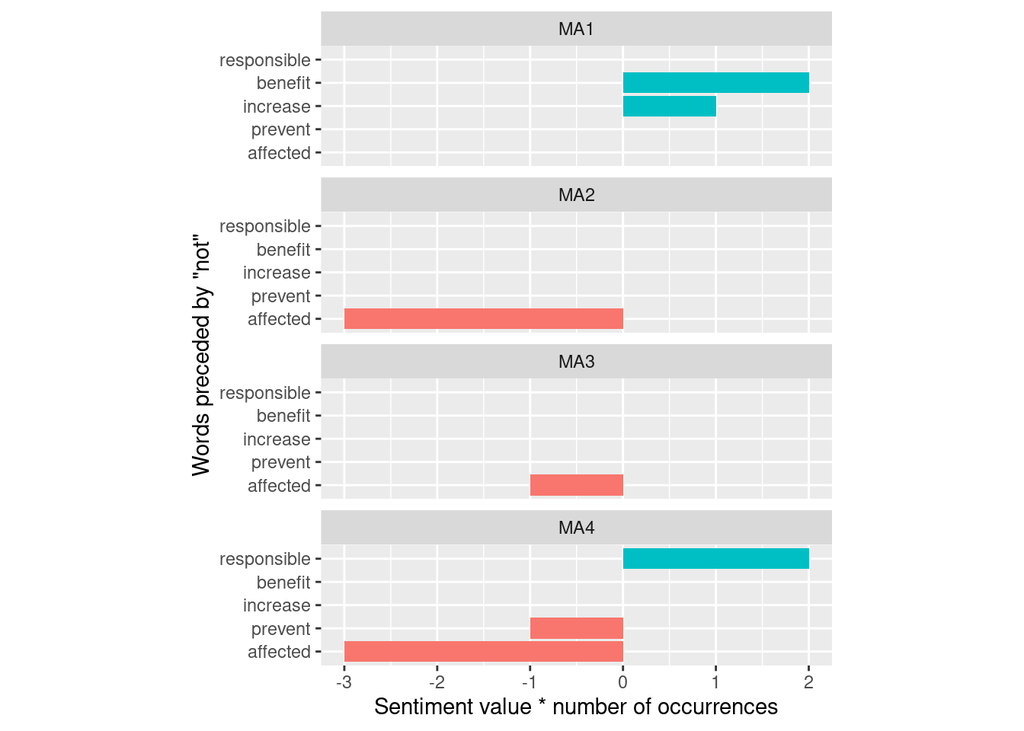

```r
not_words_with_factor <- bigrams_separated_all %>%
    filter(word1 == "not") %>%
    inner_join(AFINN, by = c(word2 = "word")) %>%
    count(MA, word2, value, sort = TRUE)

not_words_with_factor %>%
  mutate(contribution = n * value) %>%
  arrange(desc(abs(contribution))) %>%
  mutate(word2 = reorder(word2, contribution)) %>%
  ggplot(aes(contribution, word2, fill = contribution > 0)) +
  geom_col(show.legend = FALSE) +
  labs(x = "Sentiment value * number of occurrences",
       y = "Words preceded by \"not\"") +
  coord_fixed(ratio = 0.25)+
  facet_wrap(facets = vars(MA), ncol = 1)
```

```r
negation_words <- c("ain't", "aren't", "can't", "couldn't", "didn't", "doesn't", "don't", "hasn't",
                    "isn't", "mightn't", "mustn't", "neither", "never", "no", "nobody", "nor",
                    "not", "shan't", "shouldn't", "wasn't", "weren't", "won't", "wouldn't","without")
bigrams_separated_all %>%
    filter(word1 %in% negation_words) %>%
    inner_join(AFINN, by = c(word2 = "word"))
```

```
## # A tibble: 28 × 4
##    MA    word1   word2       value
##    <chr> <chr>   <chr>       <dbl>
##  1 MA1   no      significant     1
##  2 MA1   no      significant     1
##  3 MA1   not     increase        1
##  4 MA1   no      greater         3
##  5 MA1   not     benefit         2
##  6 MA1   no      significant     1
##  7 MA1   no      significant     1
##  8 MA1   neither affected       -1
##  9 MA1   no      significant     1
## 10 MA2   not     affected       -1
## # ℹ 18 more rows
```

```r
library(dplyr)
library(ggplot2)
library(tidyr)

negation_words_with_factor <- bigrams_separated_all %>%
    filter(word1 %in% negation_words) %>%
    inner_join(AFINN, by = c(word2 = "word")) %>%
    count(MA, word1, word2, value, sort = TRUE)
```

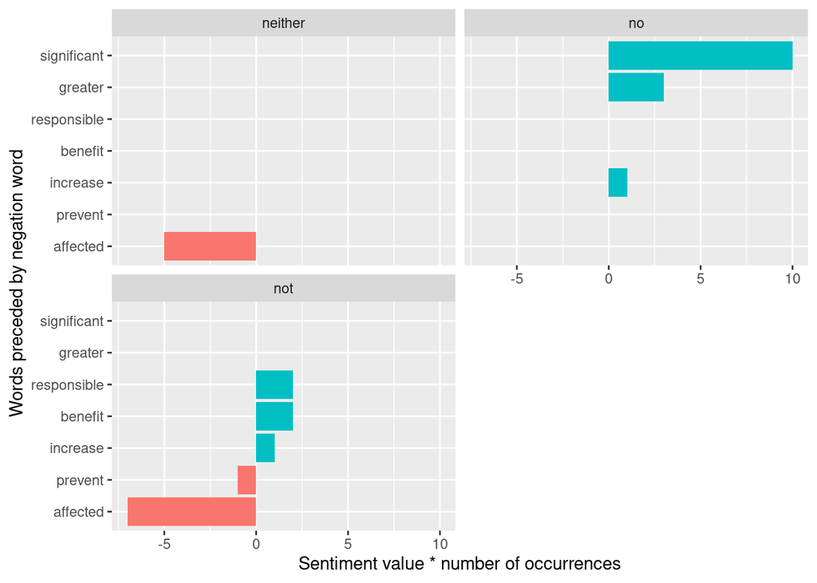

```r
negation_words_with_factor %>%
   mutate(contribution = n * value) %>%
   arrange(desc(abs(contribution))) %>%
   mutate(word2 = reorder(word2, contribution)) %>%
   ggplot(aes(contribution, word2, fill = contribution > 0)) +
   geom_col(show.legend = FALSE) +
   labs(x = "Sentiment value * number of occurrences",
        y = "Words preceded by negation word") +
   #coord_fixed(ratio = 0.25)+ : ATTENTION, peut sévèrement interférer avec l'aspect d'un plot si mal utilisé.
   facet_wrap(facets = vars(word1), ncol = 2)
```